# ST661 - Group Project - London Marathon

Group 2: Sam Alexander White, Bimal Oommen John, Akshay Suresh Varma and Fernando Nicolas Szeliga Cabezuelo

2023-11-25

```r
#data downloading

remotes::install_github("nrennie/LondonMarathon")
data(winners, package = "LondonMarathon")
data(london_marathon, package = "LondonMarathon")

#Joint London Marathon and Winners by Year

joint_marathondata <- dplyr::full_join(london_marathon, winners, by="Year")

# Time conversion from fraction of days to h:m:s

# The time column is in fraction of days,so this was converted to seconds
time_in_seconds <- as.numeric(joint_marathondata$Time) * 24 * 60 * 60

# Formatting the time components
joint_marathondata$Time_Converted <- format(as.POSIXct(time_in_seconds,origin = "1970-01-01", tz = "UTC"), format = "%H:%M:%S")


# NEW VARIABLE: GEOGRAPHICAL LOCATION

winners_countries <- unique(joint_marathondata$Nationality)


geolocation_vector <- sapply(joint_marathondata$Nationality, function(x)
{

  if (x== "Norway" | x=="Ireland" |x== "Denmark" |x== "Poland" |x== "Sweden" | x=="Portugal" |x== "France" |x== "Germany" |x== "Belgium" |x== "Switzerland" |x== "Spain" |x== "Italy" | x=="Netherlands")
  {
    return("Rest of Europe")
  }
    else if (x== "United Kingdom")
  {
    return("United Kingdom")
  }
  else if (x== "United States" |x== "Canada" |x== "Mexico")
  {
    return("North America")
  }
  else if (x== "Japan" |x== "Soviet Union" |x== "China")
  {
    return("Asia")
  }
  else if (x== "Kenya" |x== "Morocco" |x== "Ethiopia")
  {
    return("Africa")
  }
  else (x == "Australia")
  {
    return("Oceania")
  }

})

joint_marathondata$`Winner's Geographical Location` <- geolocation_vector
```

### **Introduction**

The London Marathon (also known as TCS London Marathon for sponsorship reasons) is an annual marathon held in London, England.It is the second largest annual road race in the UK, after the Great North Run in Newcastle. The largely flat course is set around the River Thames, starting in Blackheath and finishing at The Mall.

#### **Data Description**

https://github.com/nrennie/LondonMarathon#winners : The dataset comprises two fundamental divisions, namely “london_marathon” and “winners.” The former provides a comprehensive view of the marathon’s yearly broad statistics such as number of applicants, accepted applicants, number of starters, number of finishers, amount of money raised for charity (£MM), and chosen charities. The latter focuses on the winners in four competition categories: Men, Women, Wheelchair Men and Wheelchair Women. This data shares the winner’s name, nationality, and finishing time in fraction of days.

#### **Research Questions**

The following three research questions are being assessed in this report:

**Question 1: In what ways has the London Marathon’s popularity fluctuated over time?** To comprehend the variations, conducting a thorough examination of the acceptance ratio across different years would offer comprehensive insights.

**Question 2: Are Kenyan winners the fastest overall in the male and female competition?** Assessing the correlation between time taken to finish the race in relation to nationality is key to forming conclusive insights.

**Question 3: Are men’s finish times similar to women’s finish time?** Examining the completion times for men and women, coupled with a graph illustrating the time discrepancy across various years, would offer valuable insights.

### Data Wrangling

Both datasets,“winners” and “London Marathon”, were combined by year to create a single dataset. Research question 1 was answered with the “London Marathon” dataset and research questions 2 and 3 were answered with the “winners” dataset.

We finized not to use the “Raised” and “Official charities” columns in our analysis due to their high number of null values, as these columns did not significantly contribute to our research.

Notably, we didn’t collect information on the 2022–2023 handicap and found gaps in charity and money raised data. This ensures our analysis hones in on crucial aspects.

There are some interesting points in the data. In 2020, there were many applicants, likely affected by COVID-19, leading to fewer accepted participants. Also, in 1991, a winner is listed from the Soviet Union, but remember, the Soviet Union dissolved that year. These quirks add intrigue to the data and highlight the importance of careful analysis.

#### **Data Overview**

During the period of 1981 to 2019 (excluding peak COVID-19 years 2020-2023), the London Marathon saw an average of around 125,000 applicants, with approximately 40,000 accepted participants. However, the average number of individuals commencing the marathon experienced a reduction of over 25%, totaling around 29,000 participants during the same period. Notably, the majority of those who start the marathon successfully reach the finish line.

After categorizing marathon winners based on larger geographical regions such as Africa, Asia, North America, Oceania, Rest of Europe, and the United Kingdom (grouped separately as the host country), it was observed that winners emerged in every category from North America, Rest of Europe, and the United Kingdom. Asian participants claimed victory in all categories except Wheelchair Men. African participants secured wins exclusively in the Men and Women categories, while runners from Oceania (comprising 3 Australian participants) triumphed solely in the Wheelchair Men and Wheelchair Women categories.

The data highlights the distribution of triumphs across various categories in the London Marathon. In the Men’s competition, Kenya leads with 17 victories, trailed by the United Kingdom with 6 and Norway with 1. Similarly, in the Women’s division, Kenya maintains its dominance with 14 wins, while the United Kingdom and Norway follow with 7 and 6 victories, respectively.

Shifting attention to the Wheelchair events, the United Kingdom leads in both Men’s and Women’s categories with 16 and 15 victories, respectively. Switzerland secures the second position in Wheelchair Men with 6 wins and in Wheelchair Women with 4 wins. The United States closely follows, attaining 2 victories in Wheelchair Men and 6 victories in Wheelchair Women. This comprehensive dataset offers a nuanced perspective on the distribution of triumphs across nations and categories in the London Marathon.

### Analysis

**Research Q1:** In what ways has the London Marathon’s popularity fluctuated over time?

In 2020, a sharp decline to 0.0168% likely resulted from the global COVID-19 pandemic, causing event cancellations or severe restrictions. The absence of data for 2021-2023 hints at ongoing uncertainties or disruptions, possibly linked to the lingering impact of the pandemic or other unforeseen challenges. These trends underscore the complex interplay of factors influencing the London Marathon’s appeal, from its early stability to peaks, declines, and recent uncertainties, offering a multifaceted narrative of the event’s evolving dynamics.

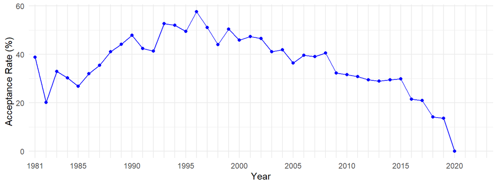

**Figure 1:** Acceptance Rate Over the Years

```r
joint_marathondata$Acceptance_Rate <- (joint_marathondata$Accepted / joint_marathondata$Applicants) * 100
subset_years <- c(1981,1985,1990, 1995, 2000, 2005, 2010, 2015, 2020)

ggplot(joint_marathondata, aes(x = factor(Year), y = Acceptance_Rate, group = 1)) +
  geom_line(color = "blue") +
  geom_point(color = "blue") +
  labs(x = "Year", y = "Acceptance Rate (%)") +
  scale_x_discrete(labels = function(x) ifelse(as.numeric(x) %in% subset_years, x, "")) +
  theme_minimal()
```

**Research Q2:** Are Kenyan winners the fastest overall in the male and female competition?

Figures 2a and 2b below represent the average finish time of London’s Marathon winners by nationality in the male and female categories respectively.

On average for the male category, Kenya was the country with the quickest finishing time. For females, it was the Netherlands. While this indicates they had the lowest mean time value, we cannot determine if this holds true for all runners of these nationalities. The data set is limited as we cannot determine the nationality of each applicant. Kenya had 17 male winners while the netherlands had 1 female winner. The sample size for each nationality varies hugely, which could be improved by obtaining more data on the applicant’s nationality.

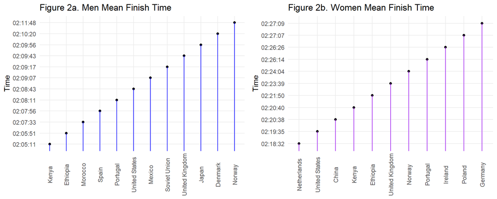

**Figure 2:** Comparison of Men and Women Winners Finish Time

```r
# Time comparison by Nationality Plot. Category: Men
joint_marathondata %>%
  filter(Category == "Men") %>%
  group_by(Nationality) %>%
  summarise(finish_time = mean(Time)) -> men_category

# The time column is in fraction of days, so this was converted to seconds
time_men <- as.numeric(men_category$finish_time) * 24 * 60 * 60

# Formatting the time components
men_category$time_conversion <- format(as.POSIXct(time_men, origin = "1970-01-01", tz = "UTC"), format = "%H:%M:%S")

p_male <- ggplot(men_category, aes(x = reorder(Nationality, finish_time, decreasing = FALSE), y = time_conversion)) +
  geom_point() +
  geom_segment(aes(xend = fct_reorder(Nationality, finish_time)), yend = 0, col = "blue") +
  theme_minimal() +
  theme(axis.text.x = element_text(angle = 90, hjust = 0.5, vjust = 0.5),
        axis.ticks.x = element_blank(),
        axis.title.x = element_blank()) +
  labs(y = "Time", title = "Figure 2a. Men Mean Finish Time")

# Time comparison by Nationality Plot. Category: Women
joint_marathondata %>%
  filter(Category == "Women") %>%
  group_by(Nationality) %>%
  summarise(finish_time = mean(Time)) %>%
  arrange(finish_time) -> women_category

# The time column is in fraction of days, so this was converted to seconds
time_women <- as.numeric(women_category$finish_time) * 24 * 60 * 60

# Formatting the time components
women_category$time_conversion <- format(as.POSIXct(time_women, origin = "1970-01-01", tz = "UTC"), format = "%H:%M:%S")

p_female <- ggplot(women_category, aes(x = reorder(Nationality, finish_time, decreasing = FALSE), y = time_conversion)) +
  geom_point() +
  geom_segment(aes(xend = fct_reorder(Nationality, finish_time)), yend = 0, col = "purple") +
  theme_minimal() +
  theme(axis.text.x = element_text(angle = 90, hjust = 0.5, vjust = 0.5),  # Rotate x-axis labels vertically
        axis.ticks.x = element_blank(),
        axis.title.x = element_blank()) +
  labs(y = "Time", title = "Figure 2b. Women Mean Finish Time")

# Arrange the plots using grid.arrange
grid.arrange(p_male, p_female, ncol = 2)
```

**Research Question 3:** Are Men’s Finishing Times Similar To That of Women’s?**

```r
# New Separation Different To Fernando
# Men
winners %>%
  filter(Category == "Men") %>%
  group_by(Year, Nationality) %>%
  summarise(finish_time = mean(Time)) %>%
  mutate(time_seconds = finish_time * 24 * 60 * 60,
         time_conversion = format(as.POSIXct(time_seconds, origin = "1970-01-01", tz = "UTC"), format = "%H:%M:%S")) -> men_data

# Women
winners %>%
  filter(Category == "Women") %>%
  group_by(Year, Nationality) %>%
  summarise(finish_time = mean(Time)) %>%
  mutate(time_seconds = finish_time * 24 * 60 * 60,
         time_conversion = format(as.POSIXct(time_seconds, origin = "1970-01-01", tz = "UTC"), format = "%H:%M:%S")) -> women_data
```

In examining the question of whether male winners are faster than their female competition, and by how much, an analysis of winners’ times revealed a consistent trend (Fig 3a). Across corresponding years, the male winners consistently achieved faster finishing times compared to their female counterparts. To visualize and quantify these differences, a scatter plot was constructed, with the y-axis representing the time differences in minutes between genders, and the x-axis denoting the year the data was recorded from. This is shown below in Fig 3b.

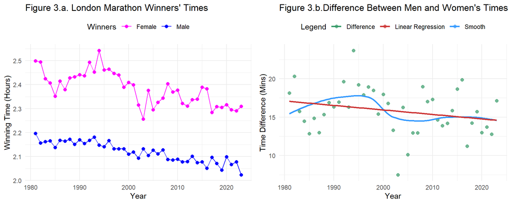

**Figure 3:** Men and women’s race times compared over the years

```r
grid.arrange(MenVsWomen, diff_plot, ncol = 2)
```

The regression line fitted to the data exhibited a negative slope, indicating a decreasing trend in the time differences over the years. This suggests that, on average, the historical gap in athletic performance and finishing times between male and female winners has been diminishing. The smooth curvature observed in the regression line adds nuance to the analysis, hinting at potential factors influencing the convergence of winning times over time. Further exploration into the underlying variables contributing to this trend could provide valuable insights into the evolving dynamics of performance in marathon competitions.

### Conclusions

our analysis of the London Marathon data revealed several key insights. Over the years, the marathon’s popularity has shown dynamic fluctuations, influenced by factors such as media coverage, international participation, and unforeseen events like the COVID-19 pandemic.

Kenyan winners demonstrated exceptional performance in the Men’s category, while the Women’s category saw a diverse set of nationalities leading, with the Netherlands emerging as the fastest.

The examination of finish times between Men and Women highlighted a decreasing trend in the historical gap, indicating a progressive convergence in athletic performance. The data offers a nuanced understanding of the marathon’s evolving dynamics, providing valuable insights for future analyses and considerations.

### Group 2 Work Distribution

When beginning the project, we decided to analyse the data from different perspectives beginning with eight questions established as a team. From here, after noticing certain trends and strong evidence in the data, we narrowed down our analysis into the questions presented in this report. Regardless if the code for original questions was used or not, we combined our work as there was sufficient overlap. These findings assisted our understanding of the data sets and led to a more refined analysis. The content of the report was completed as follows:

Data Overview & Wrangling: Akshay Analysis 1: Bimal Analysis 2: Fernando Analysis 3: Sam